# Individual Differences

# 1 Overview of the notebook

This notebook looks at how personal traits (PC and EC) affect any benefits of novelty or curiosity on memory.

There are several ways of doing this:

1. First of all, the trait scores can be the PC score or EC score or the mean of the two (`as a general score for curiosity as a trait?`).
2. Traits’ influence on **novelty** effects.
   - This can be done by examining the interaction between the PC/EC/mean scores and *Novelty* in a repeated ANOVA.
   - This can also be done by calculating the correlation between the PC and EC scores and the difference in memory performance between the *familiar* and *novel* groups
3. Traits’ influence on **curiosity** effects.
   - Calculate the correlation between the PC and EC scores and the relationship (slope) between the curiosity and memory performance.
     - This could be done by including PC/EC/mean into the model and checking the parameters for the interaction.

# 2 Novelty effects

## 2.1 Correlation between trait scores and difference between *familiar* and *novel* groups.

### 2.1.1 Inside the rooms

#### 2.1.1.1 Recollection

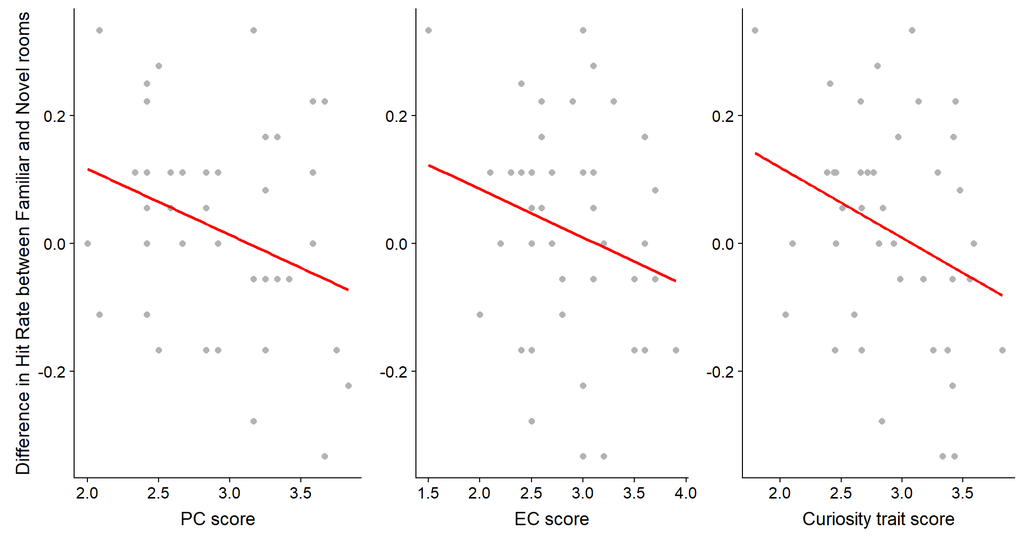

```r
cor.test(MemoryDifference$diffSeenHitInside, MemoryDifference$PC, method = "pearson")
```

```
##
##  Pearson's product-moment correlation
##
## data:  MemoryDifference$diffSeenHitInside and MemoryDifference$PC
## t = -2.0027, df = 38, p-value = 0.05238
## alternative hypothesis: true correlation is not equal to 0
## 95 percent confidence interval:
##  -0.566015895  0.002791123
## sample estimates:
##        cor
## -0.3089869
```

```r
cor.test(MemoryDifference$diffSeenHitInside, MemoryDifference$EC, method = "pearson")
```

```
##
##  Pearson's product-moment correlation
##
## data:  MemoryDifference$diffSeenHitInside and MemoryDifference$EC
## t = -1.4768, df = 38, p-value = 0.148
## alternative hypothesis: true correlation is not equal to 0
## 95 percent confidence interval:
##  -0.50764004  0.08468351
## sample estimates:
##        cor
## -0.2329716
```

```r
cor.test(MemoryDifference$diffSeenHitInside, MemoryDifference$GN, method = "pearson")
```

```
##
##  Pearson's product-moment correlation
##
## data:  MemoryDifference$diffSeenHitInside and MemoryDifference$GN
## t = -1.9385, df = 38, p-value = 0.06002
## alternative hypothesis: true correlation is not equal to 0
## 95 percent confidence interval:
##  -0.55922928  0.01272045
## sample estimates:
##        cor
## -0.2999776
```

#### 2.1.1.2 Source memory

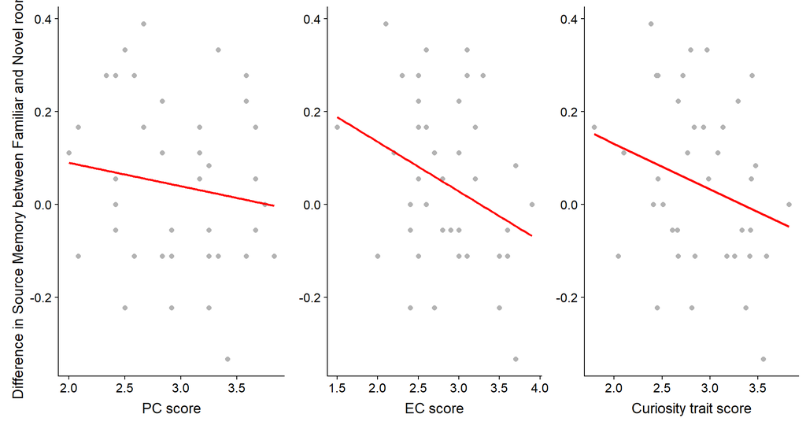

```r
cor.test(MemoryDifference$diffContextAccuracyInside, MemoryDifference$PC, method = "pearson")
```

```
##
##  Pearson's product-moment correlation
##
## data:  MemoryDifference$diffContextAccuracyInside and MemoryDifference$PC
## t = -0.91626, df = 38, p-value = 0.3653
## alternative hypothesis: true correlation is not equal to 0
## 95 percent confidence interval:
##  -0.4384512  0.1723818
## sample estimates:
##        cor
## -0.1470224
```

```r
cor.test(MemoryDifference$diffContextAccuracyInside, MemoryDifference$EC, method = "pearson")
```

```
##
##  Pearson's product-moment correlation
##
## data:  MemoryDifference$diffContextAccuracyInside and MemoryDifference$EC
## t = -2.075, df = 38, p-value = 0.04481
## alternative hypothesis: true correlation is not equal to 0
## 95 percent confidence interval:
##  -0.573528821 -0.008333241
## sample estimates:
##        cor
## -0.3190145
```

```r
cor.test(MemoryDifference$diffContextAccuracyInside, MemoryDifference$GN, method = "pearson")
```

```
##
##  Pearson's product-moment correlation
##
## data:  MemoryDifference$diffContextAccuracyInside and MemoryDifference$GN
## t = -1.6584, df = 38, p-value = 0.1055
## alternative hypothesis: true correlation is not equal to 0
## 95 percent confidence interval:
##  -0.52852365  0.05627833
## sample estimates:
##        cor
## -0.2597854
```

### 2.1.2 Outside the rooms

#### 2.1.2.1 Recollection

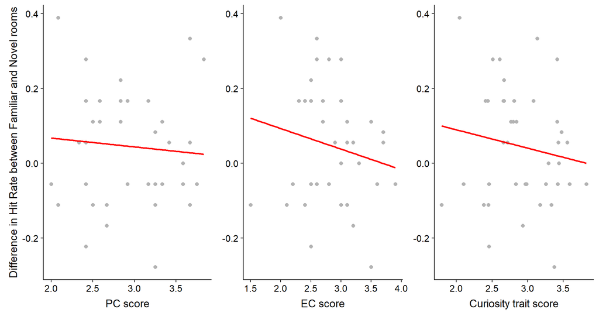

```r
cor.test(MemoryDifference$diffSeenHitOutside, MemoryDifference$PC, method = "pearson")
```

```
##
##  Pearson's product-moment correlation
##
## data:  MemoryDifference$diffSeenHitOutside and MemoryDifference$PC
## t = -0.48854, df = 38, p-value = 0.628
## alternative hypothesis: true correlation is not equal to 0
## 95 percent confidence interval:
##  -0.3811331  0.2383722
## sample estimates:
##         cor
## -0.07900357
```

```r
cor.test(MemoryDifference$diffSeenHitOutside, MemoryDifference$EC, method = "pearson")
```

```
##
##  Pearson's product-moment correlation
##
## data:  MemoryDifference$diffSeenHitOutside and MemoryDifference$EC
## t = -1.1894, df = 38, p-value = 0.2417
## alternative hypothesis: true correlation is not equal to 0
## 95 percent confidence interval:
##  -0.4730389  0.1297191
## sample estimates:
##        cor
## -0.1894455
```

```r
cor.test(MemoryDifference$diffSeenHitOutside, MemoryDifference$GN, method = "pearson")
```

```
##
##  Pearson's product-moment correlation
##
## data:  MemoryDifference$diffSeenHitOutside and MemoryDifference$GN
## t = -0.93353, df = 38, p-value = 0.3564
## alternative hypothesis: true correlation is not equal to 0
## 95 percent confidence interval:
##  -0.4406854  0.1696936
## sample estimates:
##        cor
## -0.1497307
```

#### 2.1.2.2 Source memory

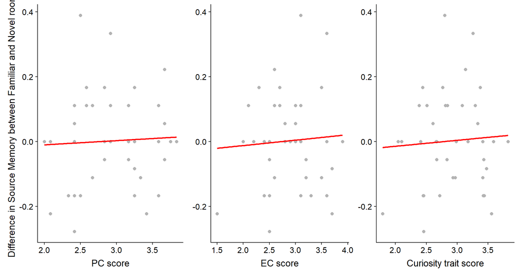

```r
cor.test(MemoryDifference$diffContextAccuracyOutside, MemoryDifference$PC, method = "pearson")
```

```
##
##  Pearson's product-moment correlation
##
## data:  MemoryDifference$diffContextAccuracyOutside and MemoryDifference$PC
## t = 0.28313, df = 38, p-value = 0.7786
## alternative hypothesis: true correlation is not equal to 0
## 95 percent confidence interval:
##  -0.2694802  0.3523540
## sample estimates:
##        cor
## 0.04588059
```

```r
cor.test(MemoryDifference$diffContextAccuracyOutside, MemoryDifference$EC, method = "pearson")
```

```
##
##  Pearson's product-moment correlation
##
## data:  MemoryDifference$diffContextAccuracyOutside and MemoryDifference$EC
## t = 0.37475, df = 38, p-value = 0.7099
## alternative hypothesis: true correlation is not equal to 0
## 95 percent confidence interval:
##  -0.2556609  0.3652856
## sample estimates:
##        cor
## 0.06068114
```

```r
cor.test(MemoryDifference$diffContextAccuracyOutside, MemoryDifference$GN, method = "pearson")
```

```
##
##  Pearson's product-moment correlation
##
## data:  MemoryDifference$diffContextAccuracyOutside and MemoryDifference$GN
## t = 0.36565, df = 38, p-value = 0.7167
## alternative hypothesis: true correlation is not equal to 0
## 95 percent confidence interval:
##  -0.2570384  0.3640073
## sample estimates:
##        cor
## 0.05921208
```

## 2.2 Curiosity effects

### 2.2.1 Inside the rooms

#### 2.2.1.1 Recollection

##### 2.2.1.1.1 Using mean of PC and EC

```
##                  Model df       AIC       BIC   logLik   Test  L.Ratio
## baseline.rating      1  3 -17.77382 -7.382326 11.88691
## rating.intercept     2  4 -16.64659 -2.791258 12.32329 1 vs 2 0.872764
## rating.slope         3  6 -14.01859  6.764396 13.00930 2 vs 3 1.372010
## GN.intercept         4  7 -12.68432 11.562504 13.34216 3 vs 4 0.665724
## GN.slope             5  8 -17.48285 10.227804 16.74142 4 vs 5 6.798532
##                  p-value
## baseline.rating
## rating.intercept  0.3502
## rating.slope      0.5036
## GN.intercept      0.4145
## GN.slope          0.0091
```

```
## Linear mixed-effects model fit by maximum likelihood
##  Data: InsideObjectsMemory_GP
##         AIC     BIC   logLik
##   -17.48285 10.2278 16.74143
##
## Random effects:
##  Formula: ~1 + CuriosityRating | SubjectNo
##  Structure: General positive-definite, Log-Cholesky parametrization
##                 StdDev     Corr
## (Intercept)     0.09647971 (Intr)
## CuriosityRating 0.01388959 0.74
## Residual        0.19876976
##
## Fixed effects: SeenHit ~ CuriosityRating + GN + CuriosityRating:GN
##                          Value  Std.Error  DF   t-value p-value
## (Intercept)         0.00578597 0.22789324 194  0.025389  0.9798
## CuriosityRating     0.12784247 0.04699653 194  2.720254  0.0071
## GN                  0.19147599 0.07799482  38  2.454983  0.0188
## CuriosityRating:GN -0.04163542 0.01599169 194 -2.603566  0.0099
##  Correlation:
##                    (Intr) CrstyR GN
## CuriosityRating    -0.701
## GN                 -0.986  0.691
## CuriosityRating:GN  0.695 -0.987 -0.704
##
## Standardized Within-Group Residuals:
##          Min           Q1          Med           Q3          Max
## -2.486091162 -0.643014086 -0.004841417  0.624754355  2.258164677
##
## Number of Observations: 236
## Number of Groups: 40
```

##### 2.2.1.1.2 Using PC and EC separately

```
##                  Model df       AIC       BIC   logLik   Test  L.Ratio
## baseline.rating      1  3 -17.77382 -7.382326 11.88691
## rating.intercept     2  4 -16.64659 -2.791258 12.32329 1 vs 2 0.872764
## rating.slope         3  6 -14.01859  6.764396 13.00930 2 vs 3 1.372010
## PC.intercept         4  7 -12.75052 11.496300 13.37526 3 vs 4 0.731927
## PC.slope             5  8 -17.75151  9.959141 16.87576 4 vs 5 7.000991
## EC.intercept         6  9 -15.83785 15.336634 16.91893 5 vs 6 0.086339
## EC.slope             7 10 -14.08381 20.554505 17.04191 6 vs 7 0.245961
##                  p-value
## baseline.rating
## rating.intercept  0.3502
## rating.slope      0.5036
## PC.intercept      0.3923
## PC.slope          0.0081
## EC.intercept      0.7689
## EC.slope          0.6199
```

```
## Linear mixed-effects model fit by maximum likelihood
##  Data: InsideObjectsMemory_GP
##         AIC      BIC   logLik
##   -17.75151 9.959141 16.87576
##
## Random effects:
##  Formula: ~1 + CuriosityRating | SubjectNo
##  Structure: General positive-definite, Log-Cholesky parametrization
##                 StdDev     Corr
## (Intercept)     0.10575317 (Intr)
## CuriosityRating 0.01324035 0.614
## Residual        0.19830729
##
## Fixed effects: SeenHit ~ CuriosityRating + PC + CuriosityRating:PC
##                          Value  Std.Error  DF    t-value p-value
## (Intercept)         0.03379272 0.21526887 194  0.1569791  0.8754
## CuriosityRating     0.11977688 0.04304945 194  2.7823089  0.0059
## PC                  0.18023831 0.07276144  38  2.4771130  0.0178
## CuriosityRating:PC -0.03853931 0.01448379 194 -2.6608579  0.0084
##  Correlation:
##                    (Intr) CrstyR PC
## CuriosityRating    -0.703
## PC                 -0.984  0.693
## CuriosityRating:PC  0.696 -0.985 -0.708
##
## Standardized Within-Group Residuals:
##        Min         Q1        Med         Q3        Max
## -2.4732452 -0.6284748  0.0107665  0.6412840  2.3382833
##
## Number of Observations: 236
## Number of Groups: 40
```

Let’s do this the other way around.

```
##                  Model df       AIC       BIC   logLik   Test  L.Ratio
## baseline.rating      1  3 -17.77382 -7.382326 11.88691
## rating.intercept     2  4 -16.64659 -2.791258 12.32329 1 vs 2 0.872764
## rating.slope         3  6 -14.01859  6.764396 13.00930 2 vs 3 1.372010
## EC.intercept         4  7 -12.36880 11.878023 13.18440 3 vs 4 0.350204
## EC.slope             5  8 -14.61363 13.097020 15.30682 4 vs 5 4.244835
## PC.intercept         6  9 -12.98843 18.186056 15.49422 5 vs 6 0.374796
## PC.slope             7 10 -14.08380 20.554515 17.04190 6 vs 7 3.095372
##                  p-value
## baseline.rating
## rating.intercept  0.3502
## rating.slope      0.5036
## EC.intercept      0.5540
## EC.slope          0.0394
## PC.intercept      0.5404
## PC.slope          0.0785
```

```
## Linear mixed-effects model fit by maximum likelihood
##  Data: InsideObjectsMemory_GP
##        AIC      BIC  logLik
##   -14.0838 20.55452 17.0419
##
## Random effects:
##  Formula: ~1 + CuriosityRating | SubjectNo
##  Structure: General positive-definite, Log-Cholesky parametrization
##                 StdDev     Corr
## (Intercept)     0.09846348 (Intr)
## CuriosityRating 0.01343709 0.753
## Residual        0.19840003
##
## Fixed effects: SeenHit ~ CuriosityRating + EC + PC + CuriosityRating:EC + CuriosityRating:PC
##                          Value  Std.Error  DF    t-value p-value
## (Intercept)        -0.00148101 0.22977476 193 -0.0064455  0.9949
## CuriosityRating     0.12904509 0.04704063 193  2.7432685  0.0067
## EC                  0.03708951 0.09154043  37  0.4051708  0.6877
## PC                  0.15579612 0.09383049  37  1.6603997  0.1053
## CuriosityRating:EC -0.00918228 0.01832303 193 -0.5011330  0.6168
## CuriosityRating:PC -0.03266372 0.01868195 193 -1.7484107  0.0820
##  Correlation:
##                    (Intr) CrstyR EC     PC     CrR:EC
## CuriosityRating    -0.699
## EC                 -0.375  0.268
## PC                 -0.460  0.315 -0.641
## CuriosityRating:EC  0.273 -0.391 -0.714  0.455
## CuriosityRating:PC  0.326 -0.461  0.456 -0.712 -0.626
##
## Standardized Within-Group Residuals:
##         Min          Q1         Med          Q3         Max
## -2.49244818 -0.63258156  0.01159162  0.65096272  2.30334125
##
## Number of Observations: 236
## Number of Groups: 40
```

#### 2.2.1.2 Source memory

```
##                  Model df        AIC       BIC   logLik   Test   L.Ratio
## baseline.rating      1  3 -100.75356 -90.36206 53.37678
## rating.intercept     2  4 -100.43340 -86.57808 54.21670 1 vs 2 1.6798458
## rating.slope         3  6  -97.68123 -76.89823 54.84061 2 vs 3 1.2478209
## PC.intercept         4  7  -96.20067 -71.95385 55.10034 3 vs 4 0.5194469
## PC.slope             5  8  -94.20094 -66.49029 55.10047 4 vs 5 0.0002704
## EC.intercept         6  9  -94.01782 -62.84334 56.00891 5 vs 6 1.8168809
## EC.slope             7 10  -94.37260 -59.73428 57.18630 6 vs 7 2.3547753
##                  p-value
## baseline.rating
## rating.intercept  0.1949
## rating.slope      0.5358
## PC.intercept      0.4711
## PC.slope          0.9869
## EC.intercept      0.1777
## EC.slope          0.1249
```

```
## Linear mixed-effects model fit by maximum likelihood
##  Data: InsideObjectsMemory_GP
##        AIC       BIC  logLik
##   -94.3726 -59.73428 57.1863
##
## Random effects:
##  Formula: ~1 + CuriosityRating | SubjectNo
##  Structure: General positive-definite, Log-Cholesky parametrization
##                 StdDev    Corr
## (Intercept)     0.1341223 (Intr)
## CuriosityRating 0.0235151 -0.896
## Residual        0.1769968
##
## Fixed effects: ContextAccuracy ~ CuriosityRating + PC + EC + CuriosityRating:PC +      CuriosityRating:EC
##                          Value  Std.Error  DF    t-value p-value
## (Intercept)         0.12701245 0.22956983 193  0.5532628  0.5807
## CuriosityRating     0.03847191 0.04610902 193  0.8343684  0.4051
## PC                 -0.02713150 0.09342575  37 -0.2904071  0.7731
## EC                  0.07721158 0.09211410  37  0.8382167  0.4073
## CuriosityRating:PC  0.01750662 0.01838170 193  0.9523941  0.3421
## CuriosityRating:EC -0.02787597 0.01826935 193 -1.5258328  0.1287
##  Correlation:
##                    (Intr) CrstyR PC     EC     CrR:PC
## CuriosityRating    -0.905
## PC                 -0.450  0.400
## EC                 -0.383  0.354 -0.642
## CuriosityRating:PC  0.410 -0.447 -0.912  0.586
## CuriosityRating:EC  0.357 -0.399  0.583 -0.914 -0.633
##
## Standardized Within-Group Residuals:
##          Min           Q1          Med           Q3          Max
## -1.977445203 -0.660491866 -0.004140252  0.683134883  3.219378012
##
## Number of Observations: 236
## Number of Groups: 40
```

Let’s do this the other way around.

```
##                  Model df        AIC       BIC   logLik   Test   L.Ratio
## baseline.rating      1  3 -100.75356 -90.36206 53.37678
## rating.intercept     2  4 -100.43340 -86.57808 54.21670 1 vs 2 1.6798458
## rating.slope         3  6  -97.68123 -76.89823 54.84061 2 vs 3 1.2478209
## EC.intercept         4  7  -96.01405 -71.76722 55.00702 3 vs 4 0.3328212
## EC.slope             5  8  -95.53278 -67.82212 55.76639 4 vs 5 1.5187288
## PC.intercept         6  9  -95.44902 -64.27453 56.72451 5 vs 6 1.9162407
## PC.slope             7 10  -94.37260 -59.73428 57.18630 6 vs 7 0.9235829
##                  p-value
## baseline.rating
## rating.intercept  0.1949
## rating.slope      0.5358
## EC.intercept      0.5640
## EC.slope          0.2178
## PC.intercept      0.1663
## PC.slope          0.3365
```

```
## Linear mixed-effects model fit by maximum likelihood
##  Data: InsideObjectsMemory_GP
##         AIC       BIC   logLik
##   -95.53278 -67.82212 55.76639
##
## Random effects:
##  Formula: ~1 + CuriosityRating | SubjectNo
##  Structure: General positive-definite, Log-Cholesky parametrization
##                 StdDev     Corr
## (Intercept)     0.13123379 (Intr)
## CuriosityRating 0.02386757 -0.87
## Residual        0.17716969
##
## Fixed effects: ContextAccuracy ~ CuriosityRating + EC + CuriosityRating:EC
##                          Value  Std.Error  DF    t-value p-value
## (Intercept)         0.09596192 0.20269393 194  0.4734326  0.6364
## CuriosityRating     0.06004893 0.04128292 194  1.4545708  0.1474
## EC                  0.06063950 0.06982425  38  0.8684591  0.3906
## CuriosityRating:EC -0.01749579 0.01415405 194 -1.2360980  0.2179
##  Correlation:
##                    (Intr) CrstyR EC
## CuriosityRating    -0.902
## EC                 -0.983  0.885
## CuriosityRating:EC  0.889 -0.983 -0.903
##
## Standardized Within-Group Residuals:
##         Min          Q1         Med          Q3         Max
## -1.95956059 -0.65605367 -0.04696034  0.72433688  3.16615498
##
## Number of Observations: 236
## Number of Groups: 40
```

### 2.2.2 Outside the rooms

#### 2.2.2.1 Recollection

```
##                  Model df       AIC       BIC   logLik   Test  L.Ratio
## baseline.rating      1  3 -58.01060 -47.61910 32.00530
## rating.intercept     2  4 -62.28458 -48.42925 35.14229 1 vs 2 6.273985
## rating.slope         3  6 -62.57440 -41.79141 37.28720 2 vs 3 4.289821
## PC.intercept         4  7 -62.08802 -37.84119 38.04401 3 vs 4 1.513612
## PC.slope             5  8 -60.08803 -32.37737 38.04401 4 vs 5 0.000012
## EC.intercept         6  9 -58.20602 -27.03153 38.10301 5 vs 6 0.117994
## EC.slope             7 10 -58.21826 -23.57994 39.10913 6 vs 7 2.012237
##                  p-value
## baseline.rating
## rating.intercept  0.0123
## rating.slope      0.1171
## PC.intercept      0.2186
## PC.slope          0.9973
## EC.intercept      0.7312
## EC.slope          0.1560
```

```
## Linear mixed-effects model fit by maximum likelihood
##  Data: OutsideObjectsMemory_GP
##         AIC       BIC   logLik
##   -58.21826 -23.57994 39.10913
##
## Random effects:
##  Formula: ~1 + CuriosityRating | SubjectNo
##  Structure: General positive-definite, Log-Cholesky parametrization
##                 StdDev     Corr
## (Intercept)     0.17873482 (Intr)
## CuriosityRating 0.02855047 -0.56
## Residual        0.17129910
##
## Fixed effects: SeenHit ~ CuriosityRating + PC + EC + CuriosityRating:PC + CuriosityRating:EC
##                          Value  Std.Error  DF    t-value p-value
## (Intercept)        -0.09086209 0.25792015 193 -0.3522877  0.7250
## CuriosityRating     0.04500776 0.04911427 193  0.9163887  0.3606
## PC                 -0.02244856 0.10428608  37 -0.2152594  0.8307
## EC                  0.13660051 0.10226661  37  1.3357293  0.1898
## CuriosityRating:PC  0.01726927 0.01949125 193  0.8860011  0.3767
## CuriosityRating:EC -0.02742397 0.01921047 193 -1.4275538  0.1550
##  Correlation:
##                    (Intr) CrstyR PC     EC     CrR:PC
## CuriosityRating    -0.762
## PC                 -0.458  0.343
## EC                 -0.381  0.297 -0.637
## CuriosityRating:PC  0.350 -0.457 -0.771  0.493
## CuriosityRating:EC  0.301 -0.394  0.491 -0.775 -0.627
##
## Standardized Within-Group Residuals:
##         Min          Q1         Med          Q3         Max
## -2.06264016 -0.63098822 -0.07105306  0.54103392  2.67058430
##
## Number of Observations: 236
## Number of Groups: 40
```

Let’s do this the other way around.

```
##                  Model df       AIC       BIC   logLik   Test  L.Ratio
## baseline.rating      1  3 -58.01060 -47.61910 32.00530
## rating.intercept     2  4 -62.28458 -48.42925 35.14229 1 vs 2 6.273985
## rating.slope         3  6 -62.57440 -41.79141 37.28720 2 vs 3 4.289821
## EC.intercept         4  7 -61.64852 -37.40170 37.82426 3 vs 4 1.074115
## EC.slope             5  8 -60.88546 -33.17480 38.44273 4 vs 5 1.236940
## PC.intercept         6  9 -59.42191 -28.24742 38.71095 5 vs 6 0.536451
## PC.slope             7 10 -58.21826 -23.57994 39.10913 6 vs 7 0.796348
##                  p-value
## baseline.rating
## rating.intercept  0.0123
## rating.slope      0.1171
## EC.intercept      0.3000
## EC.slope          0.2661
## PC.intercept      0.4639
## PC.slope          0.3722
```

```
## Linear mixed-effects model fit by maximum likelihood
##  Data: OutsideObjectsMemory_GP
##         AIC       BIC   logLik
##   -58.21826 -23.57994 39.10913
##
## Random effects:
##  Formula: ~1 + CuriosityRating | SubjectNo
##  Structure: General positive-definite, Log-Cholesky parametrization
##                 StdDev     Corr
## (Intercept)     0.17873482 (Intr)
## CuriosityRating 0.02855047 -0.56
## Residual        0.17129910
##
## Fixed effects: SeenHit ~ CuriosityRating + EC + PC + CuriosityRating:EC + CuriosityRating:PC
##                          Value  Std.Error  DF    t-value p-value
## (Intercept)        -0.09086209 0.25792015 193 -0.3522877  0.7250
## CuriosityRating     0.04500776 0.04911427 193  0.9163887  0.3606
## EC                  0.13660051 0.10226661  37  1.3357293  0.1898
## PC                 -0.02244856 0.10428608  37 -0.2152594  0.8307
## CuriosityRating:EC -0.02742397 0.01921047 193 -1.4275538  0.1550
## CuriosityRating:PC  0.01726927 0.01949125 193  0.8860011  0.3767
##  Correlation:
##                    (Intr) CrstyR EC     PC     CrR:EC
## CuriosityRating    -0.762
## EC                 -0.381  0.297
## PC                 -0.458  0.343 -0.637
## CuriosityRating:EC  0.301 -0.394 -0.775  0.491
## CuriosityRating:PC  0.350 -0.457  0.493 -0.771 -0.627
##
## Standardized Within-Group Residuals:
##         Min          Q1         Med          Q3         Max
## -2.06264016 -0.63098822 -0.07105306  0.54103392  2.67058430
##
## Number of Observations: 236
## Number of Groups: 40
```

#### 2.2.2.2 Source memory

```
##                  Model df       AIC        BIC   logLik   Test   L.Ratio
## baseline.rating      1  3 -138.5264 -128.13485 72.26317
## rating.intercept     2  4 -137.0160 -123.16065 72.50799 1 vs 2 0.4896329
## rating.slope         3  6 -133.0124 -112.22941 72.50620 2 vs 3 0.0035742
## PC.intercept         4  7 -132.6325 -108.38570 73.31626 3 vs 4 1.6201132
## PC.slope             5  8 -130.8032 -103.09255 73.40160 4 vs 5 0.1706888
## EC.intercept         6  9 -129.1000  -97.92546 73.54998 5 vs 6 0.2967437
## EC.slope             7 10 -127.1023  -92.46394 73.55113 6 vs 7 0.0023068
##                  p-value
## baseline.rating
## rating.intercept  0.4841
## rating.slope      0.9982
## PC.intercept      0.2031
## PC.slope          0.6795
## EC.intercept      0.5859
## EC.slope          0.9617
```

Let’s do this the other way around.

```
##                  Model df       AIC        BIC   logLik   Test   L.Ratio
## baseline.rating      1  3 -138.5264 -128.13485 72.26317
## rating.intercept     2  4 -137.0160 -123.16065 72.50799 1 vs 2 0.4896329
## rating.slope         3  6 -133.0124 -112.22941 72.50620 2 vs 3 0.0035742
## EC.intercept         4  7 -132.4618 -108.21498 73.23090 3 vs 4 1.4493962
## EC.slope             5  8 -130.5111 -102.80050 73.25558 4 vs 5 0.0493511
## PC.intercept         6  9 -128.9699  -97.79540 73.48494 5 vs 6 0.4587325
## PC.slope             7 10 -127.1023  -92.46394 73.55113 6 vs 7 0.1323728
##                  p-value
## baseline.rating
## rating.intercept  0.4841
## rating.slope      0.9982
## EC.intercept      0.2286
## EC.slope          0.8242
## PC.intercept      0.4982
## PC.slope          0.7160
```